# Tugas Praktikum 3 MPDW: Model Regresi dengan Peubah Lag

# Packages

```r
library(dLagM)
```

```r
library(dynlm) #data harus timeseries
library(MLmetrics) #MAPE
library(lmtest)
library(car)
library(zoo)
library(dplyr)
library(readxl)
library(readr)
```

# Data

```r
data <- read_xlsx("C:\\Users\\LENOVO\\Downloads\\data_market_share_price(1).xlsx")
str(data)
```

```
## tibble [20 × 3] (S3: tbl_df/tbl/data.frame)
##  $ Period      : num [1:20] 1 2 3 4 5 6 7 8 9 10 ...
##  $ Market share: num [1:20] 3.63 4.2 3.33 4.54 2.89 4.87 4.9 5.29 6.18 7.2 ...
##  $ Price       : num [1:20] 0.97 0.95 0.99 0.91 0.98 0.9 0.89 0.86 0.85 0.82 ...
```

```r
head(data)
```

```
## # A tibble: 6 × 3
##   Period `Market share` Price
##    <dbl>          <dbl> <dbl>
## 1      1           3.63  0.97
## 2      2           4.2   0.95
## 3      3           3.33  0.99
## 4      4           4.54  0.91
## 5      5           2.89  0.98
## 6      6           4.87  0.9
```

Peubah yang dijadikan sebagi peubah bebas (xt) adalah Market share dan peubah responnya (yt) adalah Price.

```r
t <- data$Period
t <- tibble::num(1:20)
xt <- data$`Market share`
yt <- data$Price
xt <- as.vector(xt)
yt <- as.vector(yt)
```

```r
data1 <- cbind(t, xt, yt)
data1 <- as.data.frame(data1)
str(data1)
```

```
## 'data.frame':    20 obs. of  3 variables:
##  $ t : num  1 2 3 4 5 6 7 8 9 10 ...
##  $ xt: num  3.63 4.2 3.33 4.54 2.89 4.87 4.9 5.29 6.18 7.2 ...
##  $ yt: num  0.97 0.95 0.99 0.91 0.98 0.9 0.89 0.86 0.85 0.82 ...
```

```r
head(data1)
```

```
##   t   xt   yt
## 1 1 3.63 0.97
## 2 2 4.20 0.95
## 3 3 3.33 0.99
## 4 4 4.54 0.91
## 5 5 2.89 0.98
## 6 6 4.87 0.90
```

```r
#SPLIT DATA
train<-data1[1:15,]
test<-data1[16:20,]
train <- as.data.frame(train)
test <- as.data.frame(test)
```

```r
#data time series
train.ts<-ts(train)
test.ts<-ts(test)
data.ts<-ts(data1)
```

# Eksplorasi Data

## Plot Time Series

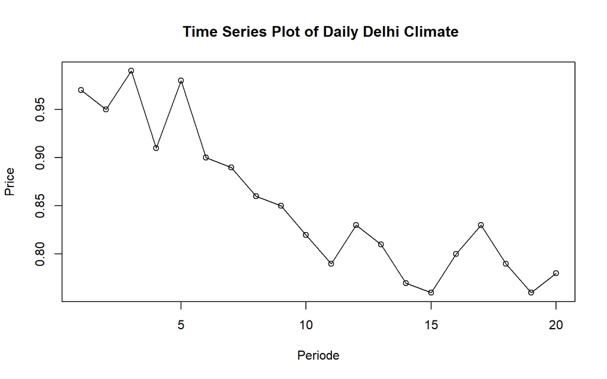

```r
data.ts1 <- ts(yt)
plot(data.ts1, main = " Time Series Plot of Daily Delhi Climate", xlab = "Periode", ylab ="Price")
points(data.ts1)
```

Berdasarkan plot time series di atas, dapat dilihat bahwa peubah Price memiliki pola turun.

## Korelasi Peubah X dan Y

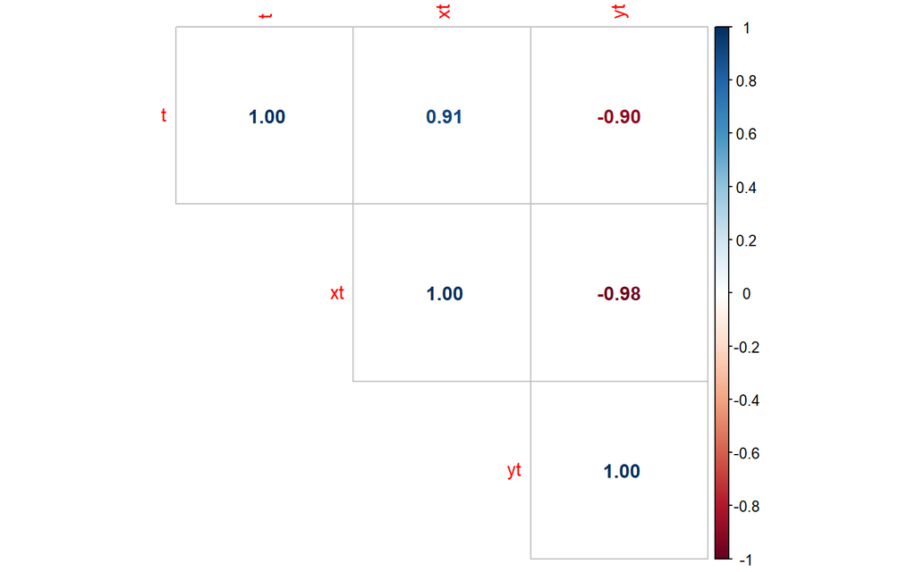

```r
corrplot::corrplot(corr=cor(data1), method="number", type="upper")
```

```r
cor(xt, yt)
```

```
## [1] -0.9752564
```

## Scatter Plot X dan Y

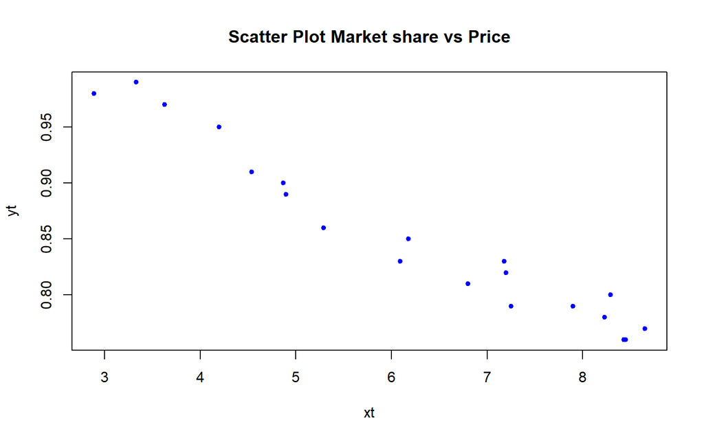

```r
plot(xt, yt, pch = 20, col = "blue", main = "Scatter Plot Market share vs Price")
```

# Model KOYCK

## Pemodelan KOYCK

```r
model.koyck <- dLagM :: koyckDlm(x=train$xt , y =train$yt)
summary(model.koyck)
```

```
##
## Call:
## "Y ~ (Intercept) + Y.1 + X.t"
##
## Residuals:
##       Min        1Q    Median        3Q       Max
## -0.035970 -0.016549 -0.005829  0.008881  0.057982
##
## Coefficients:
##             Estimate Std. Error t value Pr(>|t|)
## (Intercept)  0.43084    1.13491   0.380    0.711
## Y.1          0.58350    0.97128   0.601    0.560
## X.t         -0.01377    0.04891  -0.282    0.783
##
## Residual standard error: 0.03045 on 11 degrees of freedom
## Multiple R-Squared: 0.8586,  Adjusted R-squared: 0.8329
## Wald test: 27.25 on 2 and 11 DF,  p-value: 5.479e-05
##
## Diagnostic tests:
## NULL
##
##                             alpha        beta       phi
## Geometric coefficients:  1.034431 -0.01377439 0.5834975
```

## AIC dan BIC

```r
AIC(model.koyck)
```

```
## [1] -53.41286
```

```r
BIC(model.koyck)
```

```
## [1] -50.85663
```

## Forecasting

```r
#ramalan
(fore.koyck <- forecast(model = model.koyck, x=test$xt, h=nrow(test)))
```

```
## $forecasts
## [1] 0.7601114 0.7754660 0.7745078 0.7663728 0.7646564
##
## $call
## forecast.koyckDlm(model = model.koyck, x = test$xt, h = nrow(test))
##
## attr(,"class")
## [1] "forecast.koyckDlm" "dLagM"
```

## Akurasi

```r
mape.koyck <- MAPE(fore.koyck$forecasts, test$yt)
mape.koyck #data test
```

```
## [1] 0.03264624
```

```r
#akurasi data training
GoF(model.koyck)
```

```
##              n        MAE          MPE      MAPE      sMAPE      MASE
## model.koyck 14 0.02082298 -0.001285277 0.0231683 0.02325552 0.5524464
##                      MSE      MRAE     GMRAE
## model.koyck 0.0007285095 0.5194957 0.4530837
```

# Regression with Distributed Lag

## Pemodelan Regression with Distributed Lag (Lag = 2)

```r
model.dlm = dLagM::dlm(x = train$xt,y = train$yt , q = 2)
summary(model.dlm)
```

```
##
## Call:
## lm(formula = model.formula, data = design)
##
## Residuals:
##        Min         1Q     Median         3Q        Max
## -0.0215863 -0.0056085  0.0000912  0.0044166  0.0302927
##
## Coefficients:
##               Estimate Std. Error t value Pr(>|t|)
## (Intercept)  1.1048172  0.0177799  62.138 3.65e-13 ***
## x.t         -0.0351411  0.0047742  -7.361 4.28e-05 ***
## x.1         -0.0004779  0.0049564  -0.096    0.925
## x.2         -0.0071854  0.0054623  -1.315    0.221
## ---
## Signif. codes:  0 '***' 0.001 '**' 0.01 '*' 0.05 '.' 0.1 ' ' 1
##
## Residual standard error: 0.01609 on 9 degrees of freedom
## Multiple R-squared:  0.9638, Adjusted R-squared:  0.9517
## F-statistic: 79.83 on 3 and 9 DF,  p-value: 8.343e-07
##
## AIC and BIC values for the model:
##         AIC       BIC
## 1 -65.24952 -62.42477
```

## AIC dan BIC

```r
AIC(model.dlm)
```

```
## [1] -65.24952
```

```r
BIC(model.dlm)
```

```
## [1] -62.42477
```

## Peramalan dan Akurasi

```r
fore.dlm <- forecast(model = model.dlm, x=test$xt, h=5)
fore.dlm
```

```
## $forecasts
## [1] 0.7473153 0.7879697 0.7642045 0.7525085 0.7548033
##
## $call
## forecast.dlm(model = model.dlm, x = test$xt, h = 5)
##
## attr(,"class")
## [1] "forecast.dlm" "dLagM"
```

```r
mape.dlm <- MAPE(fore.dlm$forecasts, test$yt)
mape.dlm
```

```
## [1] 0.0382616
```

```r
#akurasi data training
GoF(model.dlm)
```

```
##            n        MAE           MPE       MAPE      sMAPE      MASE
## model.dlm 13 0.00973621 -0.0001705289 0.01123743 0.01124387 0.2596323
##                    MSE      MRAE     GMRAE
## model.dlm 0.0001793266 0.3759125 0.1231597
```

## Lag Optimum

```r
#penentuan lag optimum
finiteDLMauto(formula = yt ~ xt,
              data = data.frame(train), q.min = 1, q.max = 5 ,
              model.type = "dlm", error.type = "AIC", trace = TRUE) ##q max lag maksimum
```

```
##   q - k    MASE       AIC       BIC   GMRAE    MBRAE R.Adj.Sq  Ljung-Box
## 1     1 0.34895 -69.64036 -67.08413 0.31048 -0.81315  0.94758 0.37640987
## 3     3 0.21058 -68.53271 -65.62327 0.22189 -0.12216  0.97054 0.72377053
## 2     2 0.25963 -65.24952 -62.42477 0.12316 -0.04953  0.95171 0.58244474
## 4     4 0.24141 -59.63730 -56.85203 0.15006 -0.22193  0.96145 0.73423212
## 5     5 0.20388 -59.23162 -56.81094 0.18650 -0.05843  0.95338 0.06055224
```

## Pemodelan Lag Optimum

```r
#model dlm dengan lag optimum
model.dlm2 = dLagM::dlm(x = train$xt,y = train$yt , q = 1) #terdapat lag yang tidak signifikan sehingga dapat dikurangi jumlah lagnya
summary(model.dlm2)
```

```
##
## Call:
## lm(formula = model.formula, data = design)
##
## Residuals:
##       Min        1Q    Median        3Q       Max
## -0.024814 -0.010961 -0.004087  0.011816  0.028046
##
## Coefficients:
##              Estimate Std. Error t value Pr(>|t|)
## (Intercept)  1.104876   0.016714  66.103 1.18e-15 ***
## x.t         -0.037950   0.004545  -8.351 4.33e-06 ***
## x.1         -0.003940   0.004800  -0.821    0.429
## ---
## Signif. codes:  0 '***' 0.001 '**' 0.01 '*' 0.05 '.' 0.1 ' ' 1
##
## Residual standard error: 0.01706 on 11 degrees of freedom
## Multiple R-squared:  0.9556, Adjusted R-squared:  0.9476
## F-statistic: 118.5 on 2 and 11 DF,  p-value: 3.615e-08
##
## AIC and BIC values for the model:
##         AIC       BIC
## 1 -69.64036 -67.08413
```

## AIC dan BIC

```r
AIC(model.dlm2)
```

```
## [1] -69.64036
```

```r
BIC(model.dlm2)
```

```
## [1] -67.08413
```

## Akurasi dan Peramalan

```r
#peramalan dan akurasi
fore.dlm2 <- forecast(model = model.dlm2, x=test$xt, h=5)

#akurasi data test
mape.dlm2<- MAPE(fore.dlm2$forecasts, test$yt)
mape.dlm2
```

```
## [1] 0.02851872
```

```r
#akurasi data training
GoF(model.dlm2)
```

```
##             n        MAE           MPE       MAPE     sMAPE      MASE
## model.dlm2 14 0.01315268 -0.0002261888 0.01525278 0.0152662 0.3489486
##                     MSE      MRAE     GMRAE
## model.dlm2 0.0002285817 0.4659366 0.3104805
```

# Model Autoregressive / Dynamic Regression

## Pemodelan Model Autoregressive

```r
#MODEL AUTOREGRESSIVE
#library(dLagM)
model.ardl = ardlDlm(x = train$xt, y = train$yt, p = 1 , q = 1) #p:lag x, q:lag y
#model untuk p=1, q=1: yt=b0+b1yt-1+b2xt+b3xt-1
#model untuk p=2, q=3: yt=b0+b1yt-1+b2yt-2+b3xt+b4xt-1+b5xt-2

summary(model.ardl)
```

```
##
## Time series regression with "ts" data:
## Start = 2, End = 15
##
## Call:
## dynlm(formula = as.formula(model.text), data = data, start = 1)
##
## Residuals:
##       Min        1Q    Median        3Q       Max
## -0.020569 -0.009256 -0.002901  0.010679  0.022818
##
## Coefficients:
##              Estimate Std. Error t value Pr(>|t|)
## (Intercept)  0.706138   0.309988   2.278   0.0459 *
## X.t         -0.037059   0.004468  -8.294 8.57e-06 ***
## X.1          0.010439   0.012098   0.863   0.4084
## Y.1          0.358788   0.278547   1.288   0.2267
## ---
## Signif. codes:  0 '***' 0.001 '**' 0.01 '*' 0.05 '.' 0.1 ' ' 1
##
## Residual standard error: 0.01657 on 10 degrees of freedom
## Multiple R-squared:  0.962,  Adjusted R-squared:  0.9505
## F-statistic: 84.29 on 3 and 10 DF,  p-value: 2.122e-07
```

## AIC dan BIC

```r
AIC(model.ardl)
```

```
## [1] -69.78942
```

```r
BIC(model.ardl)
```

```
## [1] -66.59413
```

```r
model.ardl <- ardlDlm(formula = yt ~ xt,
                         data = train,p = 1 , q = 1)
summary(model.ardl)
```

```
##
## Time series regression with "ts" data:
## Start = 2, End = 15
##
## Call:
## dynlm(formula = as.formula(model.text), data = data)
##
## Residuals:
##       Min        1Q    Median        3Q       Max
## -0.020569 -0.009256 -0.002901  0.010679  0.022818
##
## Coefficients:
##              Estimate Std. Error t value Pr(>|t|)
## (Intercept)  0.706138   0.309988   2.278   0.0459 *
## xt.t        -0.037059   0.004468  -8.294 8.57e-06 ***
## xt.1         0.010439   0.012098   0.863   0.4084
## yt.1         0.358788   0.278547   1.288   0.2267
## ---
## Signif. codes:  0 '***' 0.001 '**' 0.01 '*' 0.05 '.' 0.1 ' ' 1
##
## Residual standard error: 0.01657 on 10 degrees of freedom
## Multiple R-squared:  0.962,  Adjusted R-squared:  0.9505
## F-statistic: 84.29 on 3 and 10 DF,  p-value: 2.122e-07
```

```r
AIC(model.ardl)
```

```
## [1] -69.78942
```

```r
BIC(model.ardl)
```

```
## [1] -66.59413
```

## Ramalan dan Akurasi

```r
fore.ardl <- forecast(model = model.ardl, x=test$xt, h=5)
fore.ardl
```

```
## $forecasts
## [1] 0.7596001 0.7991308 0.7750436 0.7535352 0.7597130
##
## $call
## forecast.ardlDlm(model = model.ardl, x = test$xt, h = 5)
##
## attr(,"class")
## [1] "forecast.ardlDlm" "dLagM"
```

```r
mape.ardl <- MAPE(fore.ardl$forecasts, test$yt)
mape.ardl
```

```
## [1] 0.02822781
```

```r
#akurasi data training
GoF(model.ardl)
```

```
##             n        MAE           MPE     MAPE      sMAPE      MASE
## model.ardl 14 0.01233789 -0.0002011646 0.014249 0.01425795 0.3273319
##                     MSE      MRAE     GMRAE
## model.ardl 0.0001960538 0.4197391 0.2975118
```

## Lag Optimum

```r
data <- data.frame(
  yt = data$`Market share`,
  xt = data$Price
)

model.ardl.opt <- ardlBoundOrders(
  data = data,
  ic = "AIC",
  formula = yt ~ xt
)

model.ardl.opt
```

```
## $p
##   xt
## 1  4
##
## $q
## [1] 5
##
## $Stat.table
##           q = 1     q = 2     q = 3     q = 4     q = 5     q = 6 q = 7 q = 8
## p = 1 26.443222 25.585928  27.90404  28.15440  15.86472  12.16060    NA    NA
## p = 2 25.284828 27.280557  29.39566  28.28302 -12.95797 -20.41095    NA    NA
## p = 3 29.665001 29.665001  29.54627  29.21222 -11.13376        NA    NA    NA
## p = 4 28.638892 29.730704  29.73070  25.21244 -34.02031        NA    NA    NA
## p = 5  9.600496 -1.718359 -18.02940 -18.02940        NA        NA    NA    NA
## p = 6 17.113404        NA        NA        NA        NA        NA    NA    NA
##       q = 9 q = 10 q = 11 q = 12 q = 13 q = 14 q = 15
## p = 1    NA     NA     NA     NA     NA     NA     NA
## p = 2    NA     NA     NA     NA     NA     NA     NA
## p = 3    NA     NA     NA     NA     NA     NA     NA
## p = 4    NA     NA     NA     NA     NA     NA     NA
## p = 5    NA     NA     NA     NA     NA     NA     NA
## p = 6    NA     NA     NA     NA     NA     NA     NA
##
## $min.Stat
## [1] -34.02031
```

```r
min_p=c()
for(i in 1:6){
  min_p[i]=min(model.ardl.opt$Stat.table[[i]])
}
q_opt=which(min_p==min(min_p, na.rm = TRUE))
p_opt=which(model.ardl.opt$Stat.table[[q_opt]] ==
              min(model.ardl.opt$Stat.table[[q_opt]], na.rm = TRUE))
data.frame("q_optimum" = q_opt, "p_optimum" = p_opt,
           "AIC"=model.ardl.opt$min.Stat)
```

```
##   q_optimum p_optimum       AIC
## 1         1         5 -34.02031
```

# Pemodelan DLM & ARDL dengan Library dynlm

```r
#sama dengan model dlm q=1
cons_lm1 <- dynlm(yt ~ xt+L(xt),data = train.ts)

#sama dengan model ardl p=1 q=0
cons_lm2 <- dynlm(yt ~ xt+L(yt),data = train.ts)

#sama dengan ardl p=1 q=1
cons_lm3 <- dynlm(yt ~ xt+L(xt)+L(yt),data = train.ts)

#sama dengan dlm p=2
cons_lm4 <- dynlm(yt ~ xt+L(xt)+L(xt,2),data = train.ts)
```

## Ringkasan Model

```r
summary(cons_lm1)
```

```
##
## Time series regression with "ts" data:
## Start = 2, End = 15
##
## Call:
## dynlm(formula = yt ~ xt + L(xt), data = train.ts)
##
## Residuals:
##       Min        1Q    Median        3Q       Max
## -0.024814 -0.010961 -0.004087  0.011816  0.028046
##
## Coefficients:
##              Estimate Std. Error t value Pr(>|t|)
## (Intercept)  1.104876   0.016714  66.103 1.18e-15 ***
## xt          -0.037950   0.004545  -8.351 4.33e-06 ***
## L(xt)       -0.003940   0.004800  -0.821    0.429
## ---
## Signif. codes:  0 '***' 0.001 '**' 0.01 '*' 0.05 '.' 0.1 ' ' 1
##
## Residual standard error: 0.01706 on 11 degrees of freedom
## Multiple R-squared:  0.9556, Adjusted R-squared:  0.9476
## F-statistic: 118.5 on 2 and 11 DF,  p-value: 3.615e-08
```

```r
summary(cons_lm2)
```

```
##
## Time series regression with "ts" data:
## Start = 2, End = 15
##
## Call:
## dynlm(formula = yt ~ xt + L(yt), data = train.ts)
##
## Residuals:
##       Min        1Q    Median        3Q       Max
## -0.023436 -0.010947 -0.002961  0.010547  0.026959
##
## Coefficients:
##              Estimate Std. Error t value Pr(>|t|)
## (Intercept)  0.954170   0.114699   8.319 4.50e-06 ***
## xt          -0.036421   0.004355  -8.363 4.27e-06 ***
## L(yt)        0.137002   0.106102   1.291    0.223
## ---
## Signif. codes:  0 '***' 0.001 '**' 0.01 '*' 0.05 '.' 0.1 ' ' 1
##
## Residual standard error: 0.01637 on 11 degrees of freedom
## Multiple R-squared:  0.9591, Adjusted R-squared:  0.9517
## F-statistic: 129.1 on 2 and 11 DF,  p-value: 2.307e-08
```

```r
summary(cons_lm3)
```

```
##
## Time series regression with "ts" data:
## Start = 2, End = 15
##
## Call:
## dynlm(formula = yt ~ xt + L(xt) + L(yt), data = train.ts)
##
## Residuals:
##       Min        1Q    Median        3Q       Max
## -0.020569 -0.009256 -0.002901  0.010679  0.022818
##
## Coefficients:
##              Estimate Std. Error t value Pr(>|t|)
## (Intercept)  0.706138   0.309988   2.278   0.0459 *
## xt          -0.037059   0.004468  -8.294 8.57e-06 ***
## L(xt)        0.010439   0.012098   0.863   0.4084
## L(yt)        0.358788   0.278547   1.288   0.2267
## ---
## Signif. codes:  0 '***' 0.001 '**' 0.01 '*' 0.05 '.' 0.1 ' ' 1
##
## Residual standard error: 0.01657 on 10 degrees of freedom
## Multiple R-squared:  0.962,  Adjusted R-squared:  0.9505
## F-statistic: 84.29 on 3 and 10 DF,  p-value: 2.122e-07
```

```r
summary(cons_lm4)
```

```
##
## Time series regression with "ts" data:
## Start = 3, End = 15
##
## Call:
## dynlm(formula = yt ~ xt + L(xt) + L(xt, 2), data = train.ts)
##
## Residuals:
##        Min         1Q     Median         3Q        Max
## -0.0215863 -0.0056085  0.0000912  0.0044166  0.0302927
##
## Coefficients:
##               Estimate Std. Error t value Pr(>|t|)
## (Intercept)  1.1048172  0.0177799  62.138 3.65e-13 ***
## xt          -0.0351411  0.0047742  -7.361 4.28e-05 ***
## L(xt)       -0.0004779  0.0049564  -0.096    0.925
## L(xt, 2)    -0.0071854  0.0054623  -1.315    0.221
## ---
## Signif. codes:  0 '***' 0.001 '**' 0.01 '*' 0.05 '.' 0.1 ' ' 1
##
## Residual standard error: 0.01609 on 9 degrees of freedom
## Multiple R-squared:  0.9638, Adjusted R-squared:  0.9517
## F-statistic: 79.83 on 3 and 9 DF,  p-value: 8.343e-07
```

# SSE

```r
deviance(cons_lm1)
```

```
## [1] 0.003200143
```

```r
deviance(cons_lm2)
```

```
## [1] 0.002949122
```

```r
deviance(cons_lm3)
```

```
## [1] 0.002744753
```

```r
deviance(cons_lm4)
```

```
## [1] 0.002331246
```

# Uji Encomptest

```r
#uji model
if(require("lmtest")) encomptest(cons_lm1, cons_lm2)
```

```
## Encompassing test
##
## Model 1: yt ~ xt + L(xt)
## Model 2: yt ~ xt + L(yt)
## Model E: yt ~ xt + L(xt) + L(yt)
##           Res.Df Df      F Pr(>F)
## M1 vs. ME     10 -1 1.6591 0.2267
## M2 vs. ME     10 -1 0.7446 0.4084
```

## Uji Autokorelasi Residual

```r
#durbin watson
dwtest(cons_lm1)
```

```
##
##  Durbin-Watson test
##
## data:  cons_lm1
## DW = 1.4372, p-value = 0.1012
## alternative hypothesis: true autocorrelation is greater than 0
```

```r
#durbin watson
dwtest(cons_lm2)
```

```
##
##  Durbin-Watson test
##
## data:  cons_lm2
## DW = 1.7678, p-value = 0.2717
## alternative hypothesis: true autocorrelation is greater than 0
```

```r
#durbin watson
dwtest(cons_lm3)
```

```
##
##  Durbin-Watson test
##
## data:  cons_lm3
## DW = 2.1039, p-value = 0.4588
## alternative hypothesis: true autocorrelation is greater than 0
```

```r
#durbin watson
dwtest(cons_lm4)
```

```
##
##  Durbin-Watson test
##
## data:  cons_lm4
## DW = 1.3252, p-value = 0.0636
## alternative hypothesis: true autocorrelation is greater than 0
```

Berdasarkan output di atas, pengujian non-autokorelasi dengan Durbin-Watson test semua model memiliki p-value > alpha, sehingga tidak tolak H0. Artinya semua model tidak terdapat autokorelasi.

## Uji Heterogenitas

```r
bptest(cons_lm1)
```

```
##
##  studentized Breusch-Pagan test
##
## data:  cons_lm1
## BP = 0.45832, df = 2, p-value = 0.7952
```

```r
bptest(cons_lm2)
```

```
##
##  studentized Breusch-Pagan test
##
## data:  cons_lm2
## BP = 1.0729, df = 2, p-value = 0.5848
```

```r
bptest(cons_lm3)
```

```
##
##  studentized Breusch-Pagan test
##
## data:  cons_lm3
## BP = 1.2146, df = 3, p-value = 0.7495
```

```r
bptest(cons_lm4)
```

```
##
##  studentized Breusch-Pagan test
##
## data:  cons_lm4
## BP = 2.7232, df = 3, p-value = 0.4363
```

Berdasarkan output di atas, pengujian non-autokorelasi dengan Breusch-Pagan test semua model memiliki p-value > alpha, sehingga tidak tolak H0. Artinya semua model tidak terdapat heterogenitas.

## Uji Normalitas

```r
shapiro.test(residuals(cons_lm1))
```

```
##
##  Shapiro-Wilk normality test
##
## data:  residuals(cons_lm1)
## W = 0.94726, p-value = 0.519
```

```r
shapiro.test(residuals(cons_lm2))
```

```
##
##  Shapiro-Wilk normality test
##
## data:  residuals(cons_lm2)
## W = 0.93997, p-value = 0.4179
```

```r
shapiro.test(residuals(cons_lm3))
```

```
##
##  Shapiro-Wilk normality test
##
## data:  residuals(cons_lm3)
## W = 0.93881, p-value = 0.4033
```

```r
shapiro.test(residuals(cons_lm4))
```

```
##
##  Shapiro-Wilk normality test
##
## data:  residuals(cons_lm4)
## W = 0.95933, p-value = 0.7433
```

Berdasarkan output di atas, pengujian normalitas dengan Shapiro-Wilk normality test semua model memiliki p-value > alpha, sehingga tak tolak H0. Artinya semua model memiliki sisaan yang berdistribusi normal.

# Perbandingan Model

```r
akurasi <- matrix(c(mape.koyck, mape.dlm, mape.dlm2, mape.ardl))
row.names(akurasi)<- c("Koyck","DLM 1","DLM 2","Autoregressive")
colnames(akurasi) <- c("MAPE")
akurasi
```

```
##                      MAPE
## Koyck          0.03264624
## DLM 1          0.03826160
## DLM 2          0.02851872
## Autoregressive 0.02822781
```

# Plot

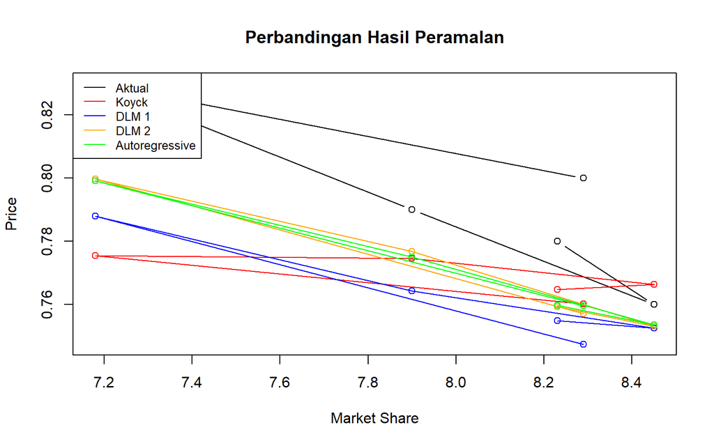

```r
# Plot Perbandingan Model
par(mfrow = c(1,1))

# Tentukan batas sumbu Y berdasarkan data aktual dan hasil ramalan
y_all <- c(
  test$yt,
  fore.koyck$forecasts,
  fore.dlm$forecasts,
  fore.dlm2$forecasts,
  fore.ardl$forecasts
)

# Plot data aktual
plot(test$xt, test$yt,
     type = "b",
     col = "black",
     ylim = range(y_all, na.rm = TRUE),
     xlab = "Market Share",
     ylab = "Price",
     main = "Perbandingan Hasil Peramalan")

# Koyck
points(test$xt, fore.koyck$forecasts, col = "red")
lines(test$xt, fore.koyck$forecasts, col = "red")

# DLM q = 2
points(test$xt, fore.dlm$forecasts, col = "blue")
lines(test$xt, fore.dlm$forecasts, col = "blue")

# DLM q = 1
points(test$xt, fore.dlm2$forecasts, col = "orange")
lines(test$xt, fore.dlm2$forecasts, col = "orange")

# ARDL
points(test$xt, fore.ardl$forecasts, col = "green")
lines(test$xt, fore.ardl$forecasts, col = "green")

# Legenda
legend("topleft",
       legend = c("Aktual", "Koyck", "DLM 1", "DLM 2", "Autoregressive"),
       lty = 1,
       col = c("black", "red", "blue", "orange", "green"),
       cex = 0.8)
```

# Simpulan

Berdasarkan perbangingan keakuratan ramalan, model yang terbaik yaitu model autoregressive karena model tersebut memiliki nilai MAPE terkecil.